# Push Data to Excel Format Using xLConnect

Segun Ojo

August 22, 2016

Here is a quick Rmarkdown to document the steps and output of the R work required. To start, I will load the necessary packages

## Load Necessary Libraries

Next I will load in the dataset

## Load Data

```r
st.panel <- tbl_df(read.csv("schularick_taylor_RRcrises_panel.csv", strip.white = TRUE))
```

## Convert Year Column to Date

From the R code snippet you sent me, it seems you want to represent each date as December 31 of each corresponding year so I included it

```r
st.panel$year <- paste(st.panel$year, "-12-31")
st.panel$year <- stri_replace_all_fixed(st.panel$year, " ", "")# use stringi to remove white space
```

Next I will convert to Posixct date using the remainder of your snippet of code

```r
st.panel$year <- as.POSIXct(strptime(st.panel$year, format = "%Y-%m-%d", tz = "GMT"))
class(st.panel$year) # confirm if year is now posixct
```

```
## [1] "POSIXct" "POSIXt"
```

## Push Data to Excel

Next is to use xLConnect package to push dataw to the excel. First I will create an empty workbook with filename WorkBook1

```r
wb <- loadWorkbook("WorkBook1.xlsx", create = TRUE)
```

Next I will create a worksheet named RRcrises inside the new WorkBook1

```r
createSheet(wb,'RRcrises')
```

Next up is to write data to my worksheet

```r
writeWorksheet(wb, as.data.frame(st.panel), sheet = "RRcrises", startRow = 1, startCol = 1)
```

Now I will format the first column (the column that will handle the date) of my worksheet to show the date

```r
yearcolumnstyle <- createCellStyle(wb) # create a new style
setDataFormat(yearcolumnstyle, format = "yyyy-m-d")   # format the style to use yyyy-m-d
setCellStyle(wb, formula='RRcrises!A1:A1950', cellstyle = yearcolumnstyle) # apply style to first column
```

Create workbook by saving

```r
saveWorkbook(wb)
```

# Notes

Doing the above steps seems to achieve the required objective but with a serious problem. Careful inspection of the output year column of the WorkBook file shows quite a handful of some dates changed automatically to 1899 e.g first row with date 1870-12-31 now have 1899-12-29. Further careful inspections shows that only dates prior to 1900 are affected.

A little more digging up shows that this is a problem of the Excel Date format as the earliest date it can handle (for a windows version is year 1900) and (for a mac version is 1904). Hence any date prior to that are forced to year 1900 or 1899 as in our case. For more information on this and how excel handles date please check out Microsoft Support Page and also page 30 of R full reference manual. Snapshot shown below for quick access

Page 30 full R reference manual:

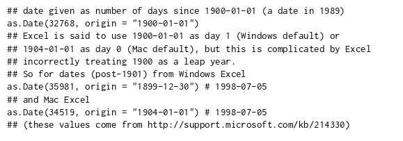

# Suggestion

I will suggest we output the date column as a string or ordinary text as excel dates prior to 1900 cannot be fully well represented in excel format. Thanks. Please let me know your thoughts.

```r
st.panel <- tbl_df(read.csv("schularick_taylor_RRcrises_panel.csv", strip.white = TRUE))
st.panel$year <- paste(st.panel$year, "-12-31")
st.panel$year <- stri_replace_all_fixed(st.panel$year, " ", "") #make sure no extra white spaces

# st.panel$year <- as.POSIXct(strptime(st.panel$year, format = "%Y-%m-%d", tz = "GMT"))
# class(st.panel$year)

wb2 <- loadWorkbook("WorkBook2.xlsx", create = TRUE)
createSheet(wb2,'RRcrises')
writeWorksheet(wb2, as.data.frame(st.panel), sheet = "RRcrises", startRow = 1, startCol = 1)
# yearcolumnstyle <- createCellStyle(wb2) # create a new style
# setDataFormat(yearcolumnstyle, format = "yyyy-m-d")   # format the style to use yyyy-m-d
# setCellStyle(wb2, formula='RRcrises!A1:A1950', cellstyle = yearcolumnstyle) # apply style to first column
saveWorkbook(wb2)
```